# car_prices_cleanup

## Context

Dataset Description: The "Vehicle Sales and Market Trends Dataset" provides a comprehensive collection of information pertaining to the sales transactions of various vehicles. This dataset encompasses details such as the make, model, body type, transmission type, state of registration, condition rating, odometer reading, exterior and interior colors, seller information, Manheim Market Report (MMR) values, selling prices, and sale dates.

Key Features: Vehicle Details: Includes specific information about each vehicle, such as its make, model, trim, and manufacturing year.

Transaction Information: Provides insights into the sales transactions, including selling prices and sale dates.

Market Trends: MMR values offer an estimate of the market value of each vehicle, allowing for analysis of market trends and fluctuations.

Condition and Mileage: Contains data on the condition of the vehicles as well as their odometer readings, enabling analysis of how these factors influence selling prices.

Potential Use Cases:

Market Analysis: Researchers and analysts can utilize this dataset to study trends in the automotive market, including pricing fluctuations based on factors such as vehicle condition and mileage.

Predictive Modeling: Data scientists can employ this dataset to develop predictive models for estimating vehicle prices based on various attributes.

Business Insights: Automotive industry professionals, dealerships, and financial institutions can derive insights into consumer preferences, market demand, and pricing strategies.

Format: The dataset is typically presented in tabular format (e.g., CSV) with rows representing individual vehicle sales transactions and columns representing different attributes associated with each transaction.

Data Integrity: Efforts have been made to ensure the accuracy and reliability of the data; however, users are encouraged to perform their own validation and verification processes.

Update Frequency: The dataset may be periodically updated to include new sales transactions and market data, providing fresh insights into ongoing trends in the automotive industry.

### 4.1 Sanity Checks

**Importing necessary libraries**

```python
# Libraries to help with reading and manipulating data
import numpy as np
import pandas as pd

# Libraries to help with data visualization
import matplotlib.pyplot as plt
import seaborn as sns

# to restrict the float value to 3 decimal places
pd.set_option('display.float_format', lambda x: '%.3f' % x)
```

**Importing the dataset**

```python
# let colab access my google drive
from google.colab import drive
drive.mount('/content/drive')
```

```python
df = pd.read_csv('/content/drive/MyDrive/car_sales/car_prices_3.csv')
```

```python
df.head()
```

|  | COMPANY | MODEL | TYPE | SIZE | transmission | state | condition | odometer | color | interior | seller | mmr | sellingprice | sale Day | Sale month | Sale year |
| --- | --- | --- | --- | --- | --- | --- | --- | --- | --- | --- | --- | --- | --- | --- | --- | --- |
| 0 | Kia | Sorento | LX | SUV | automatic | ca | 5.000 | 16639.000 | white | black | kia motors america inc | 20500.000 | 21500.000 | Tue | Dec | 2014.000 |
| 1 | Kia | Sorento | LX | SUV | automatic | ca | 5.000 | 9393.000 | white | beige | kia motors america inc | 20800.000 | 21500.000 | Tue | Dec | 2014.000 |
| 2 | BMW | 3 Series | 328i SULEV | Sedan | automatic | ca | 45.000 | 1331.000 | gray | black | financial services remarketing (lease) | 31900.000 | 30000.000 | Thu | Jan | 2015.000 |
| 3 | Volvo | S60 | T5 | Sedan | automatic | ca | 41.000 | 14282.000 | white | black | volvo na rep/world omni | 27500.000 | 27750.000 | Thu | Jan | 2015.000 |
| 4 | BMW | 6 Series Gran Coupe | 650i | Sedan | automatic | ca | 43.000 | 2641.000 | gray | black | financial services remarketing (lease) | 66000.000 | 67000.000 | Thu | Dec | 2014.000 |

**Check the data types of the columns for the dataset**

```python
df.info()
```

```
<class 'pandas.core.frame.DataFrame'>
RangeIndex: 517050 entries, 0 to 517049
Data columns (total 16 columns):
 #   Column        Non-Null Count   Dtype
---  ------        --------------   -----
 0   COMPANY       507329 non-null  object
 1   MODEL         507248 non-null  object
 2   TYPE          507020 non-null  object
 3   SIZE          504756 non-null  object
 4   transmission  457268 non-null  object
 5   state         517050 non-null  object
 6   condition     510556 non-null  float64
 7   odometer      516989 non-null  float64
 8   color         516301 non-null  object
 9   interior      516301 non-null  object
 10  seller        517050 non-null  object
 11  mmr           517039 non-null  float64
 12  sellingprice  517039 non-null  float64
 13  sale Day      517039 non-null  object
 14  Sale month    517039 non-null  object
 15  Sale year     517039 non-null  float64
dtypes: float64(5), object(11)
memory usage: 63.1+ MB
```

```python
df.isnull().sum()
```

```
COMPANY          9721
MODEL            9802
TYPE            10030
SIZE            12294
transmission    59782
state               0
condition        6494
odometer           61
color             749
interior          749
seller              0
mmr                11
sellingprice       11
sale Day           11
Sale month         11
Sale year          11
dtype: int64
```

```python
df.duplicated().sum()
```

```
0
```

```python
df.describe().T
```

|  | count | mean | std | min | 25% | 50% | 75% | max |
| --- | --- | --- | --- | --- | --- | --- | --- | --- |
| condition | 510556.000 | 30.575 | 13.319 | 1.000 | 23.000 | 34.000 | 41.000 | 49.000 |
| odometer | 516989.000 | 68720.500 | 53269.531 | 1.000 | 28856.000 | 53051.000 | 99487.000 | 999999.000 |
| mmr | 517039.000 | 13663.114 | 9582.711 | 25.000 | 7050.000 | 12200.000 | 18150.000 | 182000.000 |
| sellingprice | 517039.000 | 13510.102 | 9651.854 | 1.000 | 6800.000 | 12000.000 | 18000.000 | 230000.000 |
| Sale year | 517039.000 | 2014.911 | 0.284 | 2014.000 | 2015.000 | 2015.000 | 2015.000 | 2015.000 |

```python
df.describe(include='object').T
```

|  | count | unique | top | freq |
| --- | --- | --- | --- | --- |
| COMPANY | 507329 | 94 | Ford | 81499 |
| MODEL | 507248 | 960 | Altima | 17766 |
| TYPE | 507020 | 1920 | Base | 51463 |
| SIZE | 504756 | 85 | Sedan | 183716 |
| transmission | 457268 | 2 | automatic | 440830 |
| state | 517050 | 38 | fl | 76112 |
| color | 516301 | 19 | black | 107793 |
| interior | 516301 | 16 | black | 232332 |
| seller | 517050 | 13429 | nissan-infiniti lt | 18057 |
| sale Day | 517039 | 7 | Tue | 154473 |
| Sale month | 517039 | 8 | Feb | 151905 |

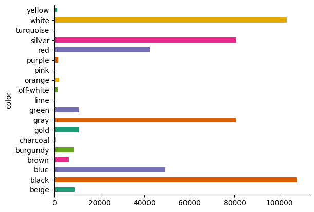

```python
from matplotlib import pyplot as plt
import seaborn as sns
df.groupby('color').size().plot(kind='barh', color=sns.palettes.mpl_palette('Dark2'))
plt.gca().spines[['top', 'right',]].set_visible(False)
```

```python
df['COMPANY'].unique()
```

```
array(['Kia', 'BMW', 'Volvo', 'Nissan', 'Chevrolet', 'Audi', 'Ford',
       'Hyundai', 'Buick', 'Cadillac', 'Acura', 'Lexus', 'Infiniti',
       'Jeep', 'Mercedes-Benz', 'Mitsubishi', 'Mazda', 'MINI',
       'Land Rover', 'Lincoln', 'lincoln', 'Jaguar', 'Volkswagen',
       'Toyota', 'Subaru', 'Scion', 'Porsche', nan, 'bmw', 'Dodge',
       'FIAT', 'Chrysler', 'ford', 'Ferrari', 'Honda', 'GMC',
       'mitsubishi', 'Ram', 'smart', 'chevrolet', 'Bentley', 'chrysler',
       'pontiac', 'Pontiac', 'Saturn', 'Maserati', 'Mercury', 'HUMMER',
       'landrover', 'cadillac', 'mercedes', 'mazda', 'toyota', 'lexus',
       'gmc truck', 'honda', 'nissan', 'porsche', 'land rover', 'Saab',
       'Suzuki', 'dodge', 'Oldsmobile', 'oldsmobile', 'jeep', 'dodge tk',
       'acura', 'subaru', 'suzuki', 'kia', 'audi', 'Rolls-Royce', 'gmc',
       'maserati', 'mercury', 'Isuzu', 'volkswagen', 'buick', 'Daewoo',
       'hyundai', 'chev truck', 'ford tk', 'plymouth', 'vw', 'Plymouth',
       'ford truck', 'Geo', 'Tesla', 'airstream', 'dot', 'Aston Martin',
       'mercedes-b', 'Fisker', 'Lamborghini', 'Lotus'], dtype=object)
```

```python
df['SIZE'].unique()
```

```
array(['SUV', 'Sedan', 'Convertible', 'Coupe', 'Wagon', 'Hatchback',
       'Crew Cab', 'G Coupe', 'G Sedan', 'Elantra Coupe', 'Genesis Coupe',
       'Minivan', nan, 'Van', 'Double Cab', 'King Cab', 'SuperCrew',
       'CTS Coupe', 'Extended Cab', 'E-Series Van', 'SuperCab',
       'Regular Cab', 'G Convertible', 'Koup', 'Quad Cab', 'CrewMax Cab',
       'CTS-V Coupe', 'sedan', 'G37 Convertible', 'Access Cab',
       'Club Cab', 'Xtracab', 'Q60 Convertible', 'CTS Wagon', 'G37 Coupe',
       'Mega Cab', 'Cab Plus 4', 'Q60 Coupe', 'Cab Plus',
       'TSX Sport Wagon', 'Promaster Cargo Van', 'Beetle Convertible',
       'GranTurismo Convertible', 'CTS-V Wagon', 'convertible', 'minivan',
       'suv', 'van', 'regular-cab', 'Transit Van', 'g sedan', 'g coupe',
       'hatchback', 'king cab', 'supercrew', 'g convertible', 'crew cab',
       'wagon', 'coupe', 'double cab', 'e-series van', 'regular cab',
       'quad cab', 'g37 convertible', 'supercab', 'extended cab',
       'crewmax cab', 'genesis coupe', 'access cab', 'mega cab',
       'xtracab', 'beetle convertible', 'cts coupe', 'koup', 'club cab',
       'elantra coupe', 'q60 coupe', 'cts-v coupe', 'transit van',
       'granturismo convertible', 'tsx sport wagon',
       'promaster cargo van', 'q60 convertible', 'g37 coupe',
       'cab plus 4', 'cts wagon'], dtype=object)
```

**What are missing values?**

Missing values occur when no data value is stored for the variable in an observation. Missing data are a common occurrence and can have a significant effect on the conclusions that can be drawn from the data.

```python
pd.DataFrame({'Count':df.isnull().sum()[df.isnull().sum()>0],'Percentage':(df.isnull().sum()[df.isnull().sum()>0]/df.shape[0])*100})
```

|  | Count | Percentage |
| --- | --- | --- |
| COMPANY | 9721 | 1.880 |
| MODEL | 9802 | 1.896 |
| TYPE | 10030 | 1.940 |
| SIZE | 12294 | 2.378 |
| transmission | 59782 | 11.562 |
| condition | 6494 | 1.256 |
| odometer | 61 | 0.012 |
| color | 749 | 0.145 |
| interior | 749 | 0.145 |
| mmr | 11 | 0.002 |
| sellingprice | 11 | 0.002 |
| sale Day | 11 | 0.002 |
| Sale month | 11 | 0.002 |
| Sale year | 11 | 0.002 |

**Removing records with missing data**

The following records will be deleted due to the following reasons:

```python
df.loc[df['mmr'].isnull()==True]
```

[output not shown]

```python
clean_df = df.dropna(subset=['mmr'])
```

```python
pd.DataFrame({'Count':clean_df.isnull().sum()[clean_df.isnull().sum()>0],'Percentage':(clean_df.isnull().sum()[clean_df.isnull().sum()>0]/clean_df.shape[0])*100})
```

|  | Count | Percentage |
| --- | --- | --- |
| COMPANY | 9721 | 1.880 |
| MODEL | 9802 | 1.896 |
| TYPE | 10030 | 1.940 |
| SIZE | 12294 | 2.378 |
| transmission | 59781 | 11.562 |
| condition | 6494 | 1.256 |
| odometer | 61 | 0.012 |
| color | 749 | 0.145 |
| interior | 749 | 0.145 |

```python
df.loc[df['color'].isnull()==True & (df['interior'].isnull()!=True)]
```

[output not shown]

```python
clean_df = clean_df.dropna(subset=['color'])
```

```python
clean_df = clean_df.dropna(subset=['odometer'])
```

```python
clean_df = clean_df.dropna(subset=['COMPANY'])
```

```python
df = df.dropna(subset=['TYPE'])
```

**Filling missing data based on other records**

We can find the missing model of some of the cars based on the other records. In this way, we are able to keep the rows of some BMW cars, and then delete few rows that it's not so clear what is their make.

```python
null_model_df = clean_df[clean_df['MODEL'].isnull()]
null_model_df.groupby(['COMPANY','TYPE']).size()
```

[output not shown]

```python
model_full = clean_df[(clean_df['COMPANY'] == 'BMW') & (clean_df['TYPE'].str.contains('750i'))]
model_full.groupby(['MODEL']).size()
```

```
MODEL
7 Series          106
ActiveHybrid 7      1
dtype: int64
```

```python
clean_df.loc[(clean_df['MODEL'].isnull()) & (clean_df['COMPANY'] == 'BMW') & (clean_df['TYPE'].str.contains('750Li')), 'MODEL'] = '7 Series'
```

```python
clean_df.loc[(clean_df['MODEL'].isnull()) & (clean_df['COMPANY'] == 'BMW') & (clean_df['TYPE'].str.contains('750i')), 'MODEL'] = '7 Series'
```

```python
clean_df = clean_df.dropna(subset=['MODEL'])
```

```python
condition_null = df.loc[df['condition'].isnull()==True]
grouped = condition_null.groupby(['COMPANY', 'MODEL', 'TYPE']).size().reset_index(name='count')
grouped[grouped['count'] > 10]
```

|  | COMPANY | MODEL | TYPE | count |
| --- | --- | --- | --- | --- |
| 3 | Acura | MDX | Touring | 14 |
| 12 | Acura | TL | 3.2 | 22 |
| 49 | BMW | 3 Series | 325i | 24 |
| 51 | BMW | 3 Series | 328i | 18 |
| 84 | BMW | X5 | 3.0i | 11 |
| ... | ... | ... | ... | ... |
| 1286 | Toyota | Highlander | Limited | 11 |
| 1294 | Toyota | Prius | Base | 21 |
| 1370 | Volkswagen | New Beetle | GLS | 11 |
| 1373 | Volkswagen | Passat | 2.0T | 11 |
| 1377 | Volkswagen | Passat | GLS 1.8T | 14 |

120 rows × 4 columns

```python
clean_df = clean_df.dropna(subset=['condition'])
```

**Changing null value to 'Unknown'**

In case of the records that are missing their size information, we will change the value to Unknown, in order to give us a chance to change it in the future if we find it's necessary.

```python
size_null = df.loc[df['SIZE'].isnull()==True]
```

```python
grouped = size_null.groupby(['COMPANY', 'MODEL', 'TYPE']).size().reset_index(name='count')
grouped[grouped['count'] > 10]
```

[output not shown]

```python
clean_df['SIZE'] = clean_df['SIZE'].fillna('Unknown')
```

**Filling transmission data based on other records**

Since there are only 2 values - manual and automatic, we assume we can fill the missing data based on the 'Mode' of this values in other cars with the same make, model, size and type. In case there is no clear decision, we set the value to 'Unknown' and later delete the few 'Unknow' records.

```python
def fill_na_with_mode(group):
    mode_val = group.mode().iloc[0] if not group.mode().empty else 'Unknown'
    return group.fillna(mode_val)

clean_df['transmission'] = clean_df.groupby(['COMPANY', 'MODEL', 'TYPE'])['transmission'].transform(fill_na_with_mode)
```

```python
clean_df.transmission.unique()
```

```
array(['automatic', 'manual', nan, 'Unknown'], dtype=object)
```

```python
trans_null = clean_df.loc[clean_df['transmission']=='Unknown']
```

```python
grouped = trans_null.groupby(['COMPANY', 'MODEL', 'TYPE']).size().reset_index(name='count')
grouped[grouped['count'] > 10]
```

|  | COMPANY | MODEL | TYPE | count |
| --- | --- | --- | --- | --- |

```python
index_to_drop = clean_df[clean_df['transmission'] == 'Unknown'].index
clean_df = clean_df.drop(index_to_drop)
clean_df = clean_df.dropna(subset=['transmission'])
```

```python
clean_df = clean_df.dropna(subset=['TYPE'])
```

```python
pd.DataFrame({'Count':clean_df.isnull().sum()[clean_df.isnull().sum()>0],'Percentage':(clean_df.isnull().sum()[clean_df.isnull().sum()>0]/clean_df.shape[0])*100})
```

|  | Count | Percentage |
| --- | --- | --- |

```python
clean_df['SIZE'].unique()
```

```
array(['SUV', 'Sedan', 'Convertible', 'Coupe', 'Wagon', 'Hatchback',
       'Crew Cab', 'G Coupe', 'G Sedan', 'Elantra Coupe', 'Genesis Coupe',
       'Minivan', 'Unknown', 'Van', 'Double Cab', 'King Cab', 'SuperCrew',
       'CTS Coupe', 'Extended Cab', 'E-Series Van', 'SuperCab',
       'Regular Cab', 'G Convertible', 'Koup', 'Quad Cab', 'CrewMax Cab',
       'CTS-V Coupe', 'sedan', 'G37 Convertible', 'Access Cab',
       'Club Cab', 'Xtracab', 'Q60 Convertible', 'CTS Wagon', 'G37 Coupe',
       'Mega Cab', 'Cab Plus 4', 'Q60 Coupe', 'TSX Sport Wagon',
       'Promaster Cargo Van', 'Cab Plus', 'Beetle Convertible',
       'GranTurismo Convertible', 'CTS-V Wagon', 'convertible', 'minivan',
       'suv', 'van', 'regular-cab', 'Transit Van', 'g sedan', 'g coupe',
       'hatchback', 'king cab', 'supercrew', 'g convertible', 'crew cab',
       'wagon', 'coupe', 'double cab', 'e-series van', 'regular cab',
       'quad cab', 'g37 convertible', 'supercab', 'extended cab',
       'crewmax cab', 'genesis coupe', 'access cab', 'mega cab',
       'xtracab', 'beetle convertible', 'cts coupe', 'koup', 'club cab',
       'elantra coupe', 'q60 coupe', 'cts-v coupe', 'transit van',
       'granturismo convertible', 'tsx sport wagon',
       'promaster cargo van', 'q60 convertible', 'g37 coupe',
       'cab plus 4', 'cts wagon'], dtype=object)
```

```python
clean_df['color'].unique()
```

```
array(['white', 'gray', 'black', 'red', 'silver', 'brown', 'beige',
       'blue', 'purple', 'burgundy', 'gold', 'yellow', 'green',
       'charcoal', 'orange', 'off-white', 'turquoise', 'pink', 'lime'],
      dtype=object)
```

```python
clean_df['SIZE'] = clean_df['SIZE'].str.lower()
```

Adding a column that holds the price gap between mmr and the actual selling price

```python
clean_df['price_gap'] = clean_df['sellingprice'] - clean_df['mmr']
```

Normalizing the condition column to be in the range of 1 to 5

```python
clean_df['condition'].unique()
```

```
array([ 5., 45., 41., 43.,  1., 34.,  2., 42.,  3., 48., 49., 17., 19.,
       29., 38., 44., 47., 32.,  4., 25., 37., 39., 31., 28., 46., 36.,
       35., 26., 21., 22., 27., 24., 33., 23., 15., 16., 18., 12., 14.,
       11., 13.])
```

```python
def condition_group(condition):
    if 1 <= condition <= 10:
        return '1'
    elif 11 <= condition <= 20:
        return '2'
    elif 21 <= condition <= 30:
        return '3'
    elif 31 <= condition <= 40:
        return '4'
    elif 41 <= condition <= 50:
        return '5'
    else:
        return 'unknown'  # Handle any other cases or invalid odometer readings
```

```python
clean_df['condition_group'] = clean_df['condition'].apply(condition_group)
```

Normalizing the odometer values into 4 groups - Low, mid, high, very high

```python
def odometer_group(odometer_reading):
    if 1 <= odometer_reading <= 30000:
        return 'low'
    elif 30001 <= odometer_reading <= 50000:
        return 'mid'
    elif 50001 <= odometer_reading <= 100000:
        return 'high'
    elif 100001 <= odometer_reading <= 999999:
        return 'very-high'
    else:
        return 'unknown'  # Handle any other cases or invalid odometer readings
```

```python
clean_df['od_group'] = clean_df['odometer'].apply(odometer_group)
```

```python
clean_df.to_csv('/content/drive/MyDrive/car_sales/clean_car_prices.csv', index = False)
```

```python
clean_df.head()
```

|  | COMPANY | MODEL | TYPE | SIZE | transmission | state | condition | odometer | color | interior | seller | mmr | sellingprice | sale Day | Sale month | Sale year | price_gap | condition_group | od_group |
| --- | --- | --- | --- | --- | --- | --- | --- | --- | --- | --- | --- | --- | --- | --- | --- | --- | --- | --- | --- |
| 0 | Kia | Sorento | LX | suv | automatic | ca | 5.000 | 16639.000 | white | black | kia motors america inc | 20500.000 | 21500.000 | Tue | Dec | 2014.000 | 1000.000 | 1 | low |
| 1 | Kia | Sorento | LX | suv | automatic | ca | 5.000 | 9393.000 | white | beige | kia motors america inc | 20800.000 | 21500.000 | Tue | Dec | 2014.000 | 700.000 | 1 | low |
| 2 | BMW | 3 Series | 328i SULEV | sedan | automatic | ca | 45.000 | 1331.000 | gray | black | financial services remarketing (lease) | 31900.000 | 30000.000 | Thu | Jan | 2015.000 | -1900.000 | 5 | low |
| 3 | Volvo | S60 | T5 | sedan | automatic | ca | 41.000 | 14282.000 | white | black | volvo na rep/world omni | 27500.000 | 27750.000 | Thu | Jan | 2015.000 | 250.000 | 5 | low |
| 4 | BMW | 6 Series Gran Coupe | 650i | sedan | automatic | ca | 43.000 | 2641.000 | gray | black | financial services remarketing (lease) | 66000.000 | 67000.000 | Thu | Dec | 2014.000 | 1000.000 | 5 | low |

```python
grouped = clean_df.groupby(['COMPANY', 'MODEL', 'TYPE','SIZE','condition_group','color', 'od_group', 'state'])['sellingprice'].agg(['mean', 'std']).reset_index()
grouped = grouped.dropna(subset=['std'])
grouped
```

|  | COMPANY | MODEL | TYPE | SIZE | condition_group | color | od_group | state | mean | std |
| --- | --- | --- | --- | --- | --- | --- | --- | --- | --- | --- |
| 54 | Acura | CL | 3.2 | coupe | 3 | white | high | fl | 4450.000 | 212.132 |
| 70 | Acura | CL | 3.2 Type-S | coupe | 2 | black | very-high | ga | 2000.000 | 1414.214 |
| 84 | Acura | CL | 3.2 Type-S | coupe | 3 | white | very-high | ca | 1925.000 | 2085.965 |
| 94 | Acura | ILX | Base | sedan | 3 | black | mid | pa | 15433.333 | 1115.049 |
| 103 | Acura | ILX | Base | sedan | 4 | black | mid | ca | 18000.000 | 0.000 |
| ... | ... | ... | ... | ... | ... | ... | ... | ... | ... | ... |
| 308302 | smart | fortwo | pure coupe | hatchback | 5 | white | low | tx | 7750.000 | 1952.562 |
| 308357 | toyota | corolla | s | unknown | 4 | black | low | fl | 11800.000 | 565.685 |
| 308362 | toyota | previa | le | unknown | 1 | white | very-high | md | 287.500 | 17.678 |
| 308399 | toyota | tundra | 4x2 v8 sr5 | unknown | 3 | white | very-high | ga | 9650.000 | 2757.716 |
| 308422 | volkswagen | passat | fwd 4c gls | unknown | 3 | black | very-high | fl | 2150.000 | 1060.660 |

73882 rows × 10 columns

```python
grouped.to_csv('/content/drive/MyDrive/car_sales/car_state_mean_std.csv', index = False)
```

```python
merged_data = pd.merge(clean_df,grouped, how='inner',on=['COMPANY', 'MODEL', 'TYPE','SIZE','condition_group','color','od_group','state'])
```

```python
merged_data.to_csv('/content/drive/MyDrive/car_sales/merged_car_state.csv', index = False)
```

```python
merged_data
```

|  | COMPANY | MODEL | TYPE | SIZE | transmission | state | condition | odometer | color | interior | ... | mmr | sellingprice | sale Day | Sale month | Sale year | price_gap | condition_group | od_group | mean | std |
| --- | --- | --- | --- | --- | --- | --- | --- | --- | --- | --- | --- | --- | --- | --- | --- | --- | --- | --- | --- | --- | --- |
| 0 | Kia | Sorento | LX | suv | automatic | ca | 5.000 | 16639.000 | white | black | ... | 20500.000 | 21500.000 | Tue | Dec | 2014.000 | 1000.000 | 1 | low | 21125.000 | 999.236 |
| 1 | Kia | Sorento | LX | suv | automatic | ca | 5.000 | 9393.000 | white | beige | ... | 20800.000 | 21500.000 | Tue | Dec | 2014.000 | 700.000 | 1 | low | 21125.000 | 999.236 |
| 2 | Kia | Sorento | LX | suv | automatic | ca | 5.000 | 5214.000 | white | black | ... | 19400.000 | 19300.000 | Tue | Dec | 2014.000 | -100.000 | 1 | low | 21125.000 | 999.236 |
| 3 | Kia | Sorento | LX | suv | automatic | ca | 5.000 | 14176.000 | white | black | ... | 20600.000 | 21250.000 | Tue | Dec | 2014.000 | 650.000 | 1 | low | 21125.000 | 999.236 |
| 4 | Kia | Sorento | LX | suv | automatic | ca | 5.000 | 11001.000 | white | black | ... | 20700.000 | 22500.000 | Tue | Dec | 2014.000 | 1800.000 | 1 | low | 21125.000 | 999.236 |
| ... | ... | ... | ... | ... | ... | ... | ... | ... | ... | ... | ... | ... | ... | ... | ... | ... | ... | ... | ... | ... | ... |
| 265214 | Honda | CR-V | LX | suv | automatic | pa | 2.000 | 221628.000 | silver | gray | ... | 5000.000 | 4100.000 | Fri | Jun | 2015.000 | -900.000 | 1 | very-high | 4350.000 | 353.553 |
| 265215 | HUMMER | H3 | Base | suv | automatic | pa | 35.000 | 76668.000 | blue | black | ... | 11750.000 | 12250.000 | Fri | Jun | 2015.000 | 500.000 | 4 | high | 12500.000 | 353.553 |
| 265216 | HUMMER | H3 | Base | suv | automatic | pa | 35.000 | 87512.000 | blue | black | ... | 11250.000 | 12750.000 | Fri | Jun | 2015.000 | 1500.000 | 4 | high | 12500.000 | 353.553 |
| 265217 | Land Rover | LR4 | HSE | suv | automatic | pa | 43.000 | 30661.000 | black | beige | ... | 42900.000 | 44500.000 | Wed | Jul | 2015.000 | 1600.000 | 5 | mid | 41650.000 | 4030.509 |
| 265218 | Land Rover | LR4 | HSE | suv | automatic | pa | 46.000 | 38489.000 | black | black | ... | 41700.000 | 38800.000 | Fri | Jun | 2015.000 | -2900.000 | 5 | mid | 41650.000 | 4030.509 |

265219 rows × 21 columns

```python
grouped_df = merged_data.groupby(['COMPANY', 'MODEL', 'TYPE', 'SIZE', 'condition_group', 'color','od_group','state']).agg(
    avg_sellingprice=('sellingprice', 'mean'),
    avg_std=('std', 'mean')
).reset_index()
sorted_df = grouped_df.sort_values(by='avg_std', ascending=False)
sorted_df.head(10)
```

|  | COMPANY | MODEL | TYPE | SIZE | condition_group | color | od_group | state | avg_sellingprice | avg_std |
| --- | --- | --- | --- | --- | --- | --- | --- | --- | --- | --- |
| 24158 | Ford | Escape | Titanium | suv | 5 | green | low | mo | 92000.000 | 119511.882 |
| 55498 | Mercedes-Benz | G-Class | G63 AMG | suv | 5 | black | low | pa | 71875.000 | 70180.348 |
| 4485 | Bentley | Continental GTC | Base | convertible | 5 | black | low | ca | 116750.000 | 58336.309 |
| 56253 | Mercedes-Benz | S-Class | S550 4MATIC | sedan | 1 | black | low | pa | 52250.000 | 44901.281 |
| 56374 | Mercedes-Benz | SL-Class | SL550 | convertible | 5 | white | low | ca | 53125.000 | 42956.737 |
| 3807 | BMW | M6 | Base | convertible | 5 | black | low | pa | 67625.000 | 42956.737 |
| 24655 | Ford | Escape | XLT | suv | 4 | red | high | oh | 26800.000 | 39982.946 |
| 51617 | Lexus | LX 570 | Base | suv | 1 | silver | high | ca | 28500.000 | 38325.188 |
| 69118 | Toyota | Corolla | LE | sedan | 3 | silver | low | nj | 30700.000 | 33094.410 |
| 6882 | Chevrolet | Corvette | Z06 | coupe | 5 | blue | low | pa | 61750.000 | 32173.359 |

```python
sorted_df.to_csv('/content/drive/MyDrive/car_sales/sorted_volatile_cars.csv', index = False)
```

```python
sorted_df.avg_std.describe()
```

```
count    73882.000
mean      1650.844
std       1903.356
min          0.000
25%        565.685
50%       1135.415
75%       2081.566
max     119511.882
Name: avg_std, dtype: float64
```